# Compscix_415.2_Homework_2

### **3.2.4.5**

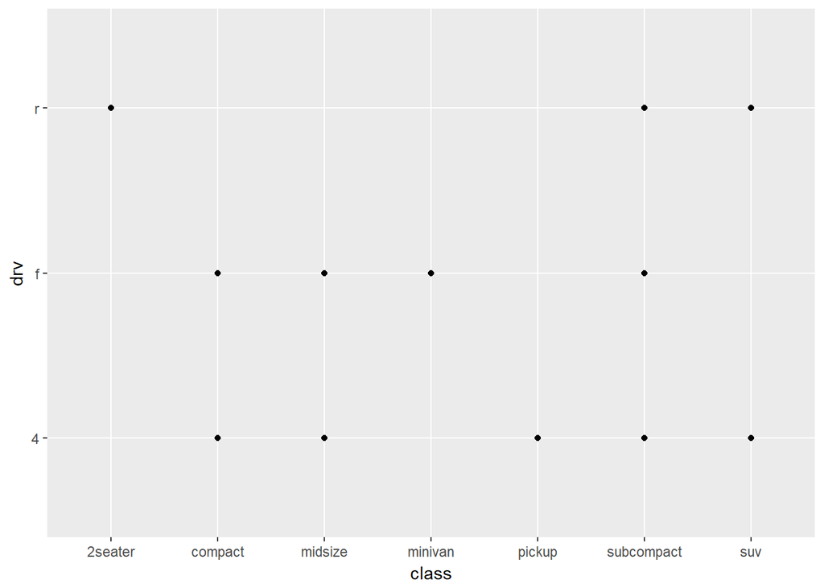

```r
ggplot(data = mpg) +
  geom_point(mapping = aes(x = class, y = drv))
```

This chart is not helpful because there is no correlation between these two variables. Class and drive show similar traits in different ways. These are also both categorical variables.

## **Section 3.3.1: all exercises**

### **3.3.1.1**

The thing that is wrong with this code is that the color aesthetic shoul be outside the mapping portion of the code. Here is a modified version with the correct color.

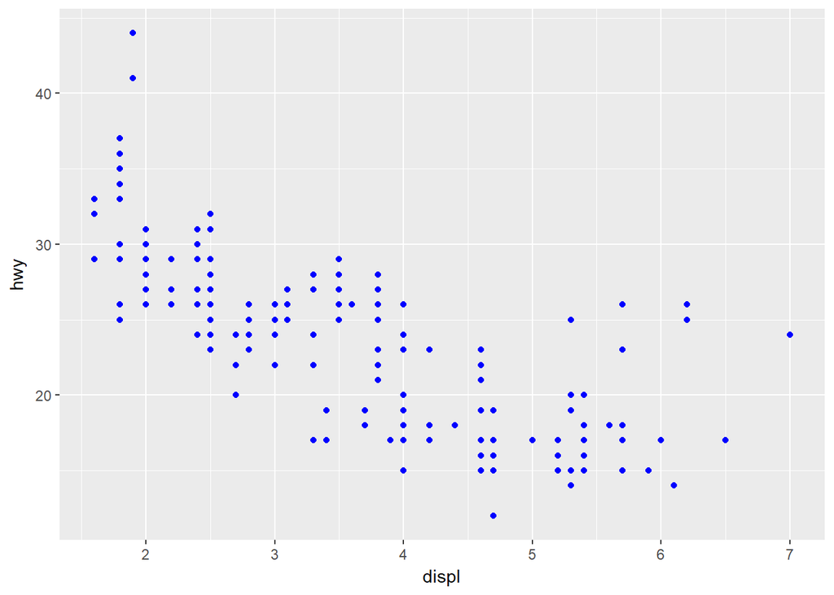

```r
ggplot(data = mpg) +
  geom_point(mapping = aes(x = displ, y = hwy), color = "blue")
```

### **3.3.1.2**

Categorical variables = manufacturer, model, displ, year, cyl, trans, drv, fl, and class Continuous variables = city and hwy. You can open a view of the mpg table in the “Environment” panel to get a glimpse of the data table.

### **3.3.1.3**

Coninuous variables can be mapped to color, and size, but they cannot be mapped to a shape. This is probably because shape is a categorical aesthetic.

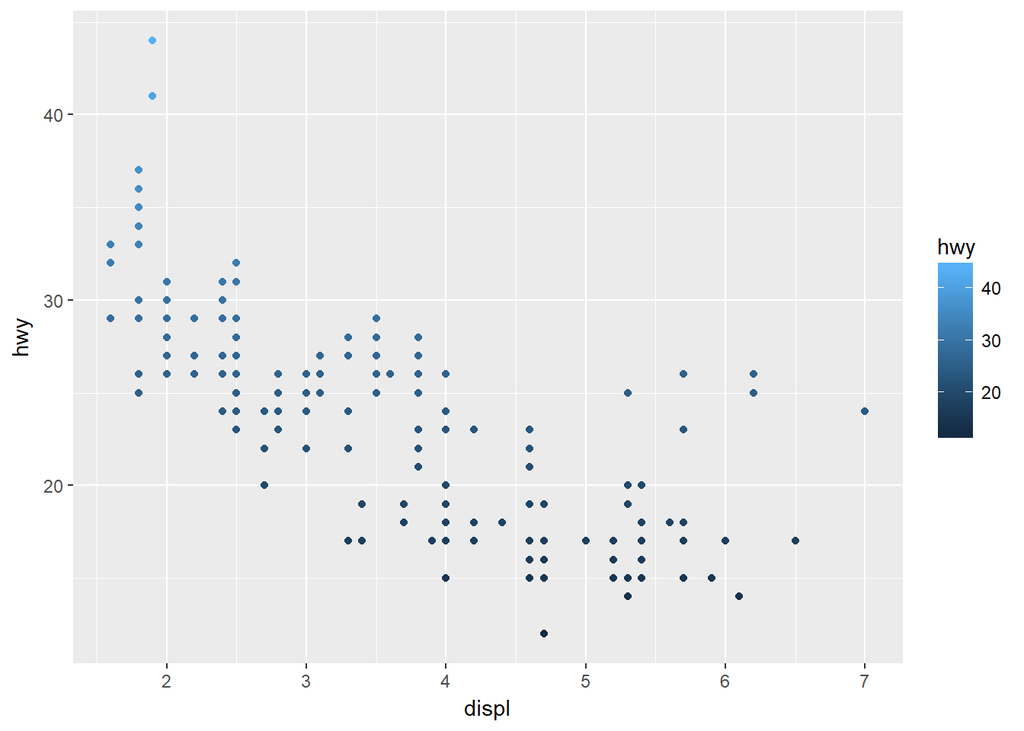

```r
ggplot(data = mpg) +
  geom_point(mapping = aes(x = displ, y = hwy, color = hwy))
```

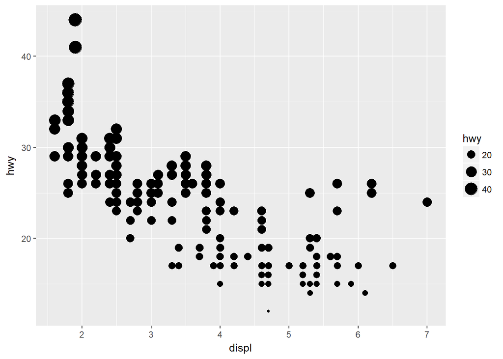

```r
ggplot(data = mpg) +
  geom_point(mapping = aes(x = displ, y = hwy, size = hwy))
```

### **3.3.1.4**

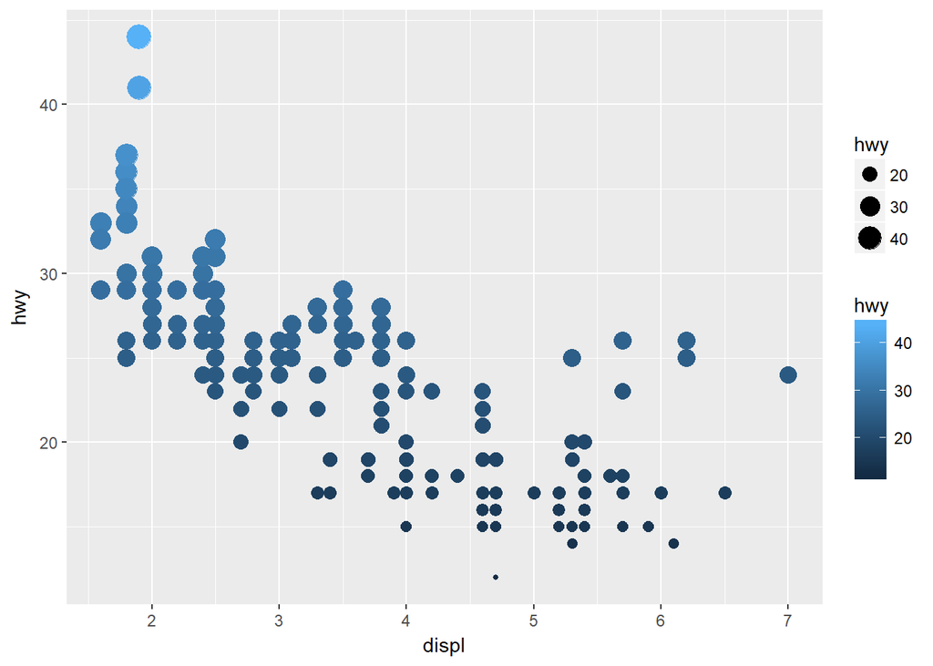

```r
ggplot(data = mpg) +
  geom_point(mapping = aes(x = displ, y = hwy, size = hwy, color = hwy))
```

If you map the same variable to multiple aesthetics the chart will run, but both of these aesthetics show the same thing.

### **3.3.1.5**

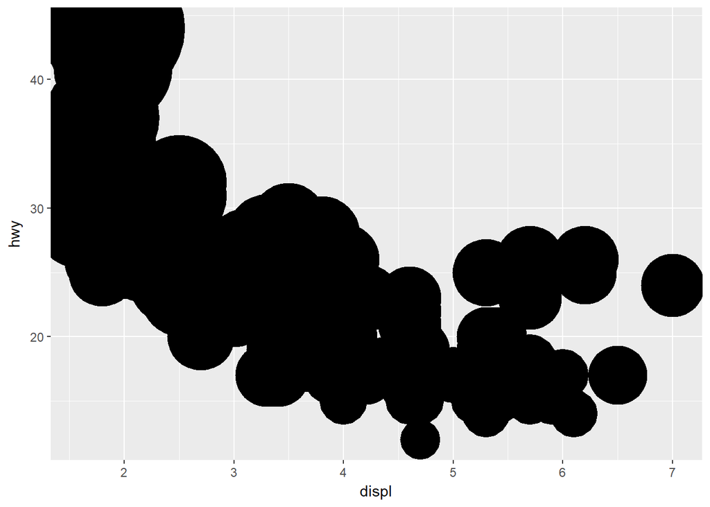

```r
ggplot(data = mpg) +
  geom_point(mapping = aes(x = displ, y = hwy, stroke = cty))
```

The stroke aesthetic creates shapes of different sizes to differentiate continuous data. The stroke aesthetic works for all shapes.

### **3.3.1.6**

If you map an aesthetic to something other than a variable name, the aesthetic will be used to differentiate the variable you set it to. In the example below, the aesthetic is used to differentiate two different boolean variables on the displ variable.

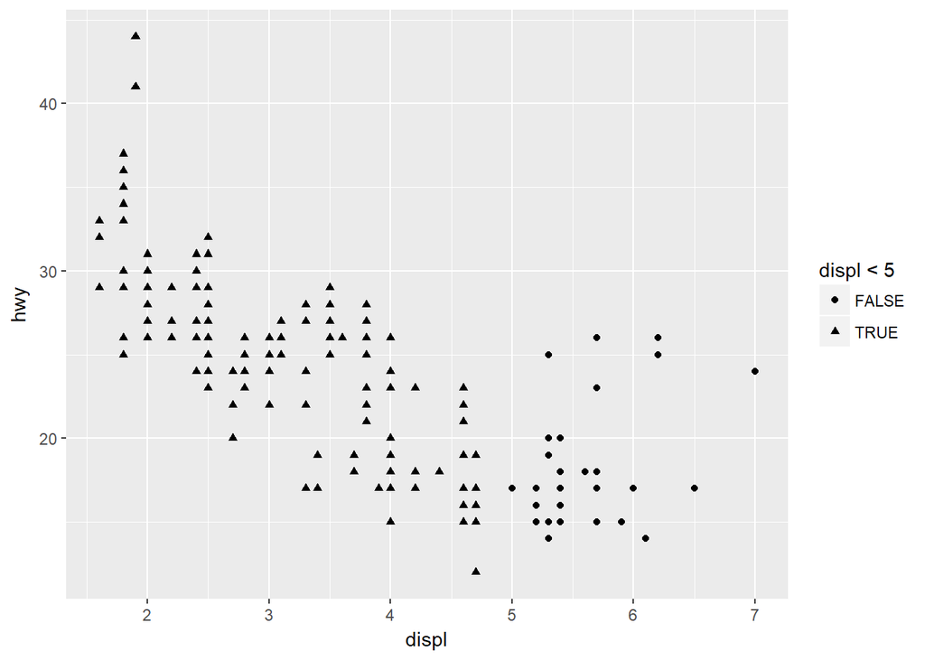

```r
ggplot(data = mpg) +
  geom_point(mapping = aes(x = displ, y = hwy, shape = displ<5))
```

## **Section 3.5.1: #4 and #5 only**

### **3.5.1.4**

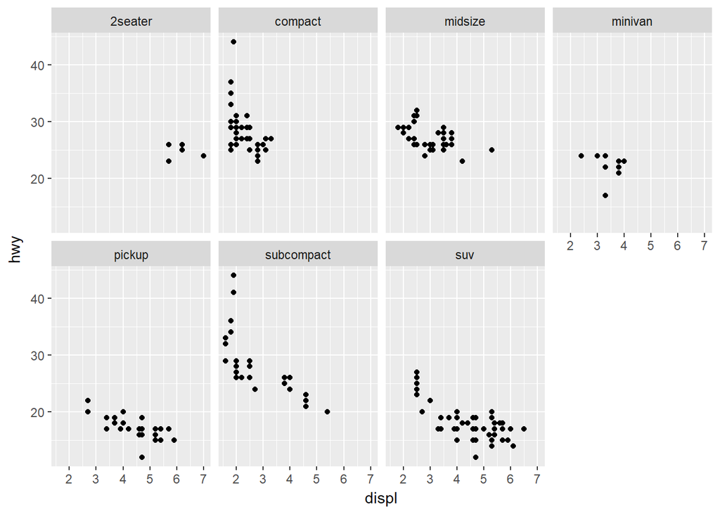

```r
ggplot(data = mpg) +
  geom_point(mapping = aes(x = displ, y = hwy)) +
  facet_wrap(~ class, nrow = 2)
```

The advantages to using faceting instead od the color aesthetic is faceting groups datapoints into discrete categories which makes it easier to differentiate the aspects of each faceted category. One of the disadvantages is that it is difficult to see a big picture trend over all categories in the data.

### **3.5.1.5**

nrow determines the number of rows of panels. ncol determines the number of columns of panels. Some other options to control the layout of individual panels are scales, shrink, labeller, as.table, switch, drop, dir, and strip.position. facet_grid() doesn’t have nrow and ncol argument because the numbers of rows and columns are determined by the number of combinations of the variables that exist in the data.

## **Section 3.6.1: #1-5.**

### **3.6.1.1**

Here are the geoms for each chart type. line chart = geom_smooth(). boxplot = geom_boxplot(). histogram = geom_histogram() area = geom_area()

### **3.6.1.2**

This code will map displ v hwy with three different colors to show the categorical variable drv as a scatterplot with three smooth lines showing the relationship between displ and hwy for each of the three variables.

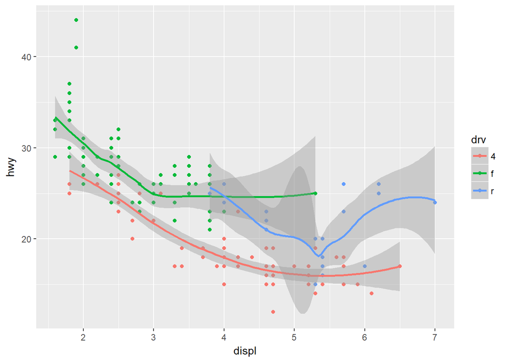

```r
ggplot(data = mpg, mapping = aes(x = displ, y = hwy, color = drv)) +
  geom_point() +
  geom_smooth(se = TRUE)
```

### **3.6.1.3**

The show.legend = FALSE function hides the legend from the chart, when you remove it the legend appears automatically. The reason it was used earlier in this chapter was because the example chart was used to show three different ways to present a smooth line chart and the legend only applied to one chart.

### **3.6.1.4**

The se argument in geom_smooth() determines whether or not to show the shaded region alongside a smoothed line which represents the variance in the data.

### **3.6.1.5**

The two graphs mentioned will not look different because they are both displaying the same data on one chart. The code for the first graph is just a short-hand version of the code for the second graph.

## **Extra Credit: Do #6**

### **3.6.1.6**

**graph 1**

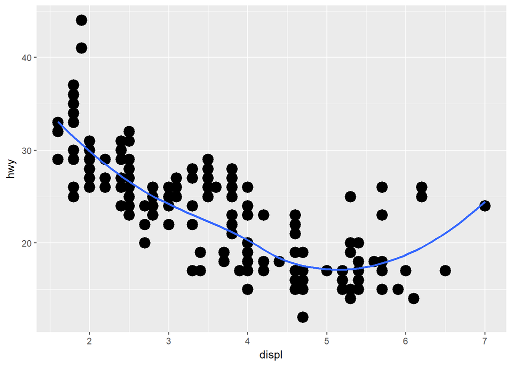

```r
ggplot(data = mpg, mapping = aes(x = displ, y = hwy)) +
  geom_point(stroke = 3) + geom_smooth(se = FALSE)
```

**graph 2**

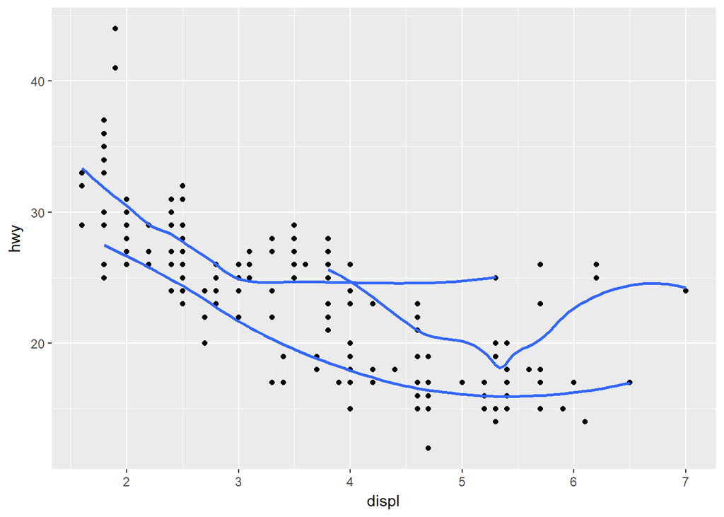

```r
ggplot(data = mpg) +
  geom_point(mapping = aes(x = displ, y = hwy)) + geom_smooth(mapping = aes(x = displ, y = hwy, group = drv), show.legend = FALSE, se = FALSE)
```

**graph 3**

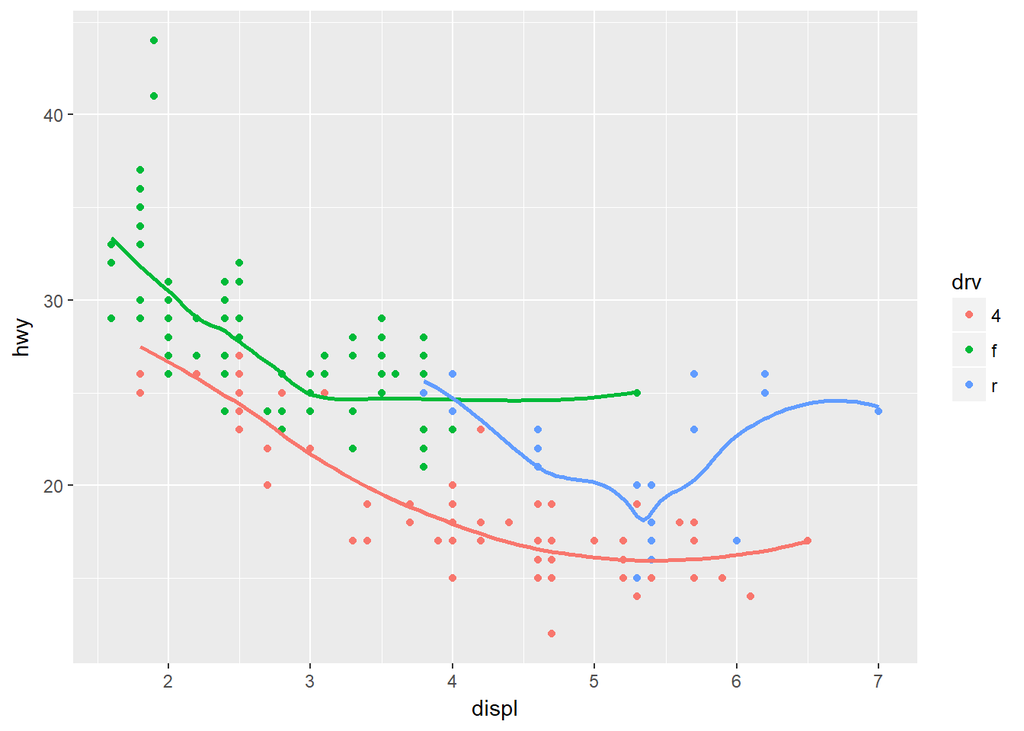

```r
ggplot(data = mpg) +
  geom_point(mapping = aes(x = displ, y = hwy,color = drv)) + geom_smooth(mapping = aes(x = displ, y = hwy, color = drv), show.legend = FALSE, se = FALSE)
```

**graph 4**

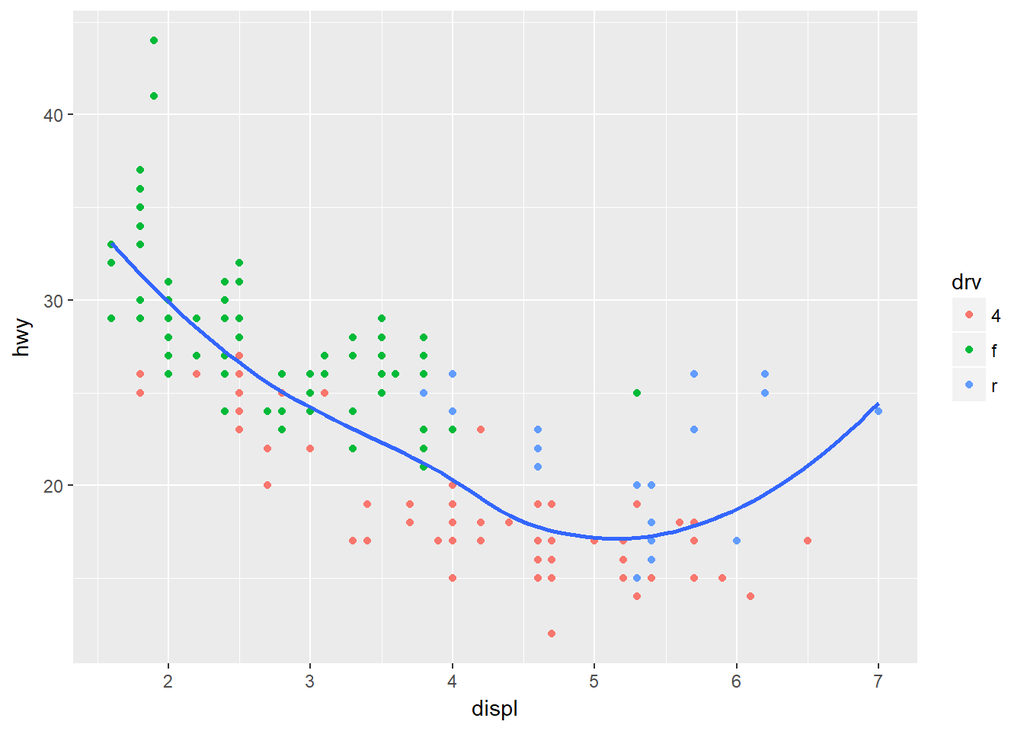

```r
ggplot(data = mpg) +
  geom_point(mapping = aes(x = displ, y = hwy,color = drv)) + geom_smooth(mapping = aes(x = displ, y = hwy), show.legend = FALSE, se = FALSE)
```

**graph 5**

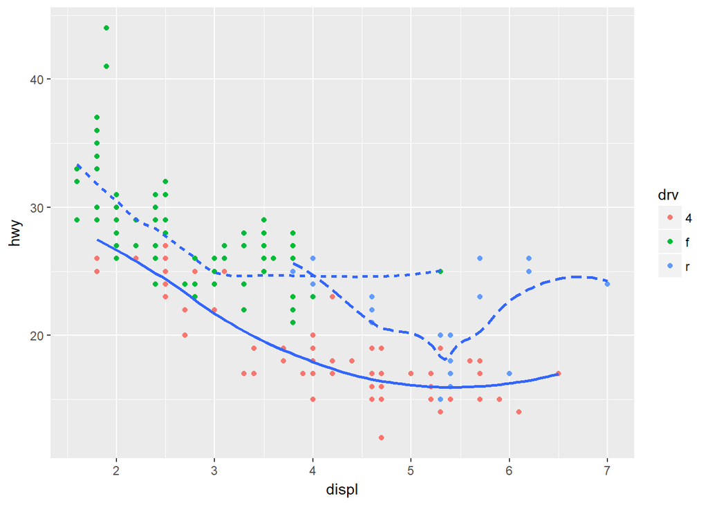

```r
ggplot(data = mpg) +
  geom_point(mapping = aes(x = displ, y = hwy,color = drv)) + geom_smooth(mapping = aes(x = displ, y = hwy, linetype = drv), show.legend = FALSE, se = FALSE)
```

**graph 6**

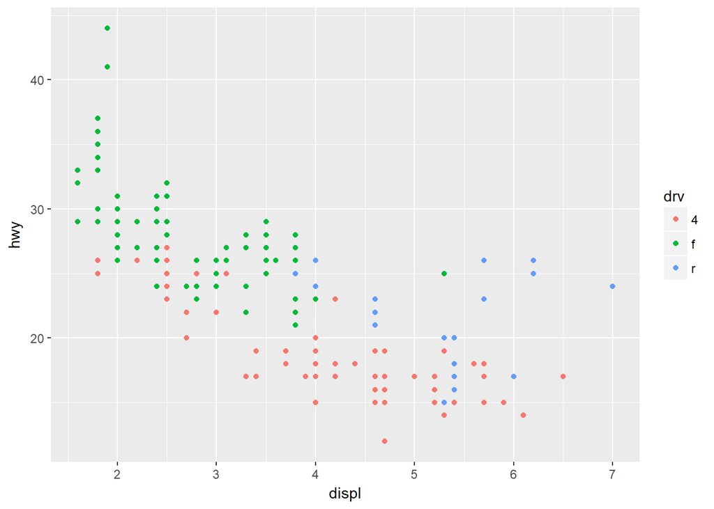

```r
ggplot(data = mpg) +
  geom_point(mapping = aes(x = displ, y = hwy, color = drv))
```

## **Section 3.7.1: #2 only**

### **3.7.1.2**

geom_col() can be used to display a column chart with a user defined y variable. It is different than geom_bar() because geom_bar() only needs an x variable defined and the y variable will be equal to the count of objects in that category.

## **What is a Data Scientist**

In some charts the overal percentage does not add up to 100%. This is noted, but the numbers should be made to add up to 100% to make logical sense. For the data lifecycle chart, this could have been displayed better with a timeline showing the lifecycle in chronoligcal order. Throughout the entire document, there is an overuse of percentages. The author should have thrown in more raw numbers.